# 作業2

請依狀況更改上面的name,id及group（分別代表組員姓名，學號及組號），但請「勿」更改下面姓名、學號、組號三行的設定。

姓名：林云方  
學號：710661123  
組號：9

# 勞動市場

執行以下程式引入勞動市場資料labordata，資料說明請見連結[Cornwell and Rupert Returns to Schooling Data, 595 Individuals, 7 Years.](http://people.stern.nyu.edu/wgreene/Econometrics/PanelDataSets.htm)

```r
library(readr)
labordata <- read_csv("http://people.stern.nyu.edu/wgreene/Econometrics/cornwell&rupert.csv")
```

```r
library("AER")
library("ggplot2")
library("dplyr")
library("knitr")
library(magrittr)
```

```r
str(labordata)
```

```
## Classes 'tbl_df', 'tbl' and 'data.frame':    4165 obs. of  24 variables:
##  $ EXP   : int  3 4 5 6 7 8 9 30 31 32 ...
##  $ WKS   : int  32 43 40 39 42 35 32 34 27 33 ...
##  $ OCC   : int  0 0 0 0 0 0 0 1 1 1 ...
##  $ IND   : int  0 0 0 0 1 1 1 0 0 1 ...
##  $ SOUTH : int  1 1 1 1 1 1 1 0 0 0 ...
##  $ SMSA  : int  0 0 0 0 0 0 0 0 0 0 ...
##  $ MS    : int  1 1 1 1 1 1 1 1 1 1 ...
##  $ FEM   : int  0 0 0 0 0 0 0 0 0 0 ...
##  $ UNION : int  0 0 0 0 0 0 0 0 0 1 ...
##  $ ED    : int  9 9 9 9 9 9 9 11 11 11 ...
##  $ BLK   : int  0 0 0 0 0 0 0 0 0 0 ...
##  $ LWAGE : num  5.56 5.72 6 6 6.06 ...
##  $ EXPSQ : int  9 16 25 36 49 64 81 900 961 1024 ...
##  $ YEAR  : int  1 2 3 4 5 6 7 1 2 3 ...
##  $ LOGWKS: num  3.47 3.76 3.69 3.66 3.74 ...
##  $ ID    : int  1 1 1 1 1 1 1 2 2 2 ...
##  $ EXPB  : int  6 6 6 6 6 6 6 33 33 33 ...
##  $ WKSB  : num  37.6 37.6 37.6 37.6 37.6 ...
##  $ OCCB  : num  0 0 0 0 0 0 0 1 1 1 ...
##  $ INDB  : num  0.429 0.429 0.429 0.429 0.429 ...
##  $ SOUTHB: num  1 1 1 1 1 1 1 0 0 0 ...
##  $ SMSAB : num  0 0 0 0 0 0 0 0 0 0 ...
##  $ UNIONB: num  0 0 0 0 0 ...
##  $ EXPSQB: int  40 40 40 40 40 40 40 1093 1093 1093 ...
##  - attr(*, "spec")=List of 2
##   ..$ cols   :List of 24
##   .. ..$ EXP   : list()
##   .. .. ..- attr(*, "class")= chr  "collector_integer" "collector"
##   .. ..$ WKS   : list()
##   .. .. ..- attr(*, "class")= chr  "collector_integer" "collector"
##   .. ..$ OCC   : list()
##   .. .. ..- attr(*, "class")= chr  "collector_integer" "collector"
##   .. ..$ IND   : list()
##   .. .. ..- attr(*, "class")= chr  "collector_integer" "collector"
##   .. ..$ SOUTH : list()
##   .. .. ..- attr(*, "class")= chr  "collector_integer" "collector"
##   .. ..$ SMSA  : list()
##   .. .. ..- attr(*, "class")= chr  "collector_integer" "collector"
##   .. ..$ MS    : list()
```

[output cut: 23 more lines]

```
##   .. ..$ OCCB  : list()
##   .. .. ..- attr(*, "class")= chr  "collector_double" "collector"
##   .. ..$ INDB  : list()
##   .. .. ..- attr(*, "class")= chr  "collector_double" "collector"
##   .. ..$ SOUTHB: list()
##   .. .. ..- attr(*, "class")= chr  "collector_double" "collector"
##   .. ..$ SMSAB : list()
##   .. .. ..- attr(*, "class")= chr  "collector_double" "collector"
##   .. ..$ UNIONB: list()
##   .. .. ..- attr(*, "class")= chr  "collector_double" "collector"
##   .. ..$ EXPSQB: list()
##   .. .. ..- attr(*, "class")= chr  "collector_integer" "collector"
##   ..$ default: list()
##   .. ..- attr(*, "class")= chr  "collector_guess" "collector"
##   ..- attr(*, "class")= chr "col_spec"
```

```r
labordata %<>%
 mutate(OCC=as.factor(OCC),IND=as.factor(IND),SOUTH=as.factor(SOUTH),SMSA=as.factor(SMSA),MS=as.factor(MS),FEM=as.factor(FEM),UNION=as.factor(UNION),BLK=as.factor(BLK))
```

## 勞動供給

### (1)

將labordata只留下第7年的資料

```r
labordata %<>% filter(YEAR=="7")
```

### (2)

我們想要估計薪資對工時的影響（即勞動供給），考慮如下的勞動供給函數
$$wks_{i}=\beta_0+\beta_1 lwage_{i}+\epsilon_i$$

請使用plot()畫出橫軸為每週工時（WKS）與縱軸為取對數後薪資（LWAGE, 後往直接稱呼「薪資」）的離散圖。

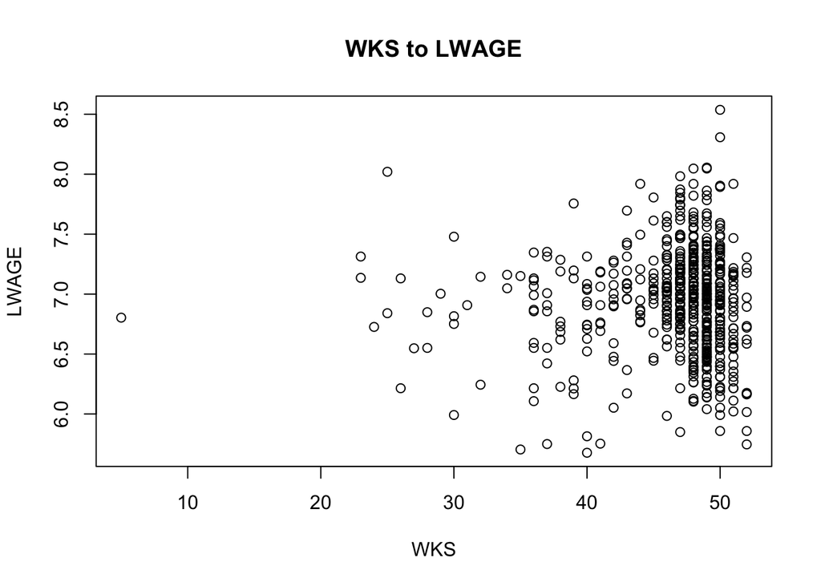

```r
plot(x=labordata$WKS,
     y=labordata$LWAGE,
     main = "WKS to LWAGE",
     xlab = "WKS",
     ylab = "LWAGE")
```

### (3)

我們擔心「勞工屬於工會」這個變數(union, 為1若屬於工會, 反之為0)遺漏的話會造成勞動供給的工資係數估計偏誤。請用文字故事說明為什麼會有這層擔心？[記得要有兩個面向故事] 這擔心應該會高估或低估工資係數？ [請不要使用任何程式或數字計算，單純文字故事邏輯]

```
面向一：勞工正常工作時間每日不得超過8小時，每週不得超過40小時，若要延長工時，必須經過工會同意，必須符合相關法令規定，因此屬於工會和每週工時之間的關係推估為負相關。
面向二：工會設立的最主要目的就是為了維護與提升勞工的勞動條件與經濟條件，勞工可以藉由工會的力量，來要求公平合理的待遇，因此屬於工會和薪資之間的關係推估為正相關。
所以這遺漏變數的擔心會低估工資係數。
```

### (4)

在不做迴歸下，請用union分組計算lwage與wks的平均，並用數字結果來支持你在(c)小題的擔心。

```r
labordata%>%
filter(UNION==1)->union1
rbind(
union1%>%
summarise(avg=mean(LWAGE),N = n()),
union1%>%
summarise(avg=mean(WKS),N = n()))
```

| avg | N |
| --- | --- |
| 6.961293 | 218 |
| 45.279817 | 218 |

```r
labordata%>%
filter(UNION==0)->union0
rbind(
union0%>%
summarise(avg=mean(LWAGE),N = n()),
union0%>%
summarise(avg=mean(WKS),N = n()))
```

| avg | N |
| --- | --- |
| 6.944645 | 377 |
| 47.129973 | 377 |

### (5)

我們最後考慮如下的複迴歸勞動供給函數
$$wks_{i}=\beta_0+\beta_1 lwage_{i} + \beta_2 ed_{i} +\beta_3 union_{i} +\beta_4 fem_{i}+\epsilon_{i}$$
請用『純文字說明』(不要寫程式，不要算任何數字)：為什麼要再放教育水準及性別二個控制變數？

```
教育水準：
面向一：教育水準越高越有較好的工作機會，因此教育水準越高薪資水準越高。
面向二：教育水準越高，薪資也越高，所以休閒的成本較高，因此工時較長。

性別：
面向一：因為女性會較顧慮於家庭，工作投入的心力較少，以至於晉升機會少，所以薪資相對低。
面向二：因為女性會較顧慮於家庭，工作投入的時間較少，所以工時會相對短。
```

### (6)

同時OLS估計簡單迴歸和複迴歸下的勞動供給，並用stargarzer呈現估計結果（請設定type=“html”）。

```r
library(sandwich)
library(lmtest)
library(stargazer)
model1<-WKS ~ LWAGE
model2<-WKS ~ LWAGE + ED + UNION + FEM
ols1<-lm(model1,labordata)
ols2<-lm(model2,labordata)
coeftest(ols1, vcov. = vcovHC, type="HC1") -> ols1_coeftest
coeftest(ols2, vcov. = vcovHC, type="HC1") -> ols2_coeftest
stargazer(ols1,ols2,
          se=list(ols1_coeftest[,"Std. Error"],
                  ols2_coeftest[,2]),
                  type ="text")
```

```
##
## ==============================================================
##                                Dependent variable:
##                     ------------------------------------------
##                                        WKS
##                             (1)                  (2)
## --------------------------------------------------------------
## LWAGE                      0.476                0.538
##                           (0.502)              (0.633)
##
## ED                                              -0.143
##                                                (0.088)
##
## UNION1                                        -2.218***
##                                                (0.477)
##
## FEM1                                           -1.612**
##                                                (0.790)
##
## Constant                 43.141***            45.539***
##                           (3.540)              (4.138)
##
## --------------------------------------------------------------
## Observations                595                  595
## R2                         0.002                0.046
## Adjusted R2               -0.0001               0.039
## Residual Std. Error  5.185 (df = 593)      5.082 (df = 590)
## F Statistic         0.964 (df = 1; 593) 7.101*** (df = 4; 590)
## ==============================================================
## Note:                              *p<0.1; **p<0.05; ***p<0.01
```

### (7)

複迴歸模型估計下，LWAGE的係數要如何詮譯？顯不顯著？

[output not shown]

### (8)

找出一個使複迴歸模型在控制變數下依然不符合條件性獨立的故事（必需牽扯到labordata資料不會有的變數，所以只能純文字故事）。

```
變數：景氣
如果景氣好，產業蓬勃發展，各地方會缺工，因此薪資會上揚。而且因為缺工，老闆會比較願意支付加班費，請員工加長工作時數，所以工時會比較長。
```

## 內生性偏誤

在(2)小題，圖形看不出明顯正斜率的勞動供給線，一個主要原因是薪資與工時是勞動供需決定的結果，因此任何影響勞動供給的因素都會影響薪資，也就是供給線的誤差項不你放多少的變數，最後誤差項還是會改變供給線，也因此一定會影響薪資——誤差項一定會和薪資變數相關。使用複迴歸不管加多少控制變數永遠不會得到薪資係數的一致性估計，這樣的狀況我們稱為內生性偏誤（endogeneity bias）。

然而內生性偏誤卻是相當容易使用工具變數解決，解決方式就是從勞動「需求」函數下手——任何影響勞動需求線的因素都會是合理的工具變數。

### (9)

在勞動市場中，產業別不同其對勞動力的需求也不一樣。另外，不同地點的勞動需求狀況也不同。使用文字邏輯說明「產業別」、勞動者「居住地」可能是合理工具變數的理由。

```
產業別和薪資相關，因為油電業和金融業薪資相對優渥，餐飲業薪資相對低，因此符合相關性條件;產業別和每週工時不相關，因為不管哪一個產業別，每週工時必須符合法令在40小時，因此符合排除條件。
居住地和薪資相關，因為薪資高者有能力買房在黃金地段及高級住宅區，因此符合相關性條件;居住地和每週工時不相關，因為不管居住地在哪，每週工時必須符合法令在40小時，因此符合排除條件。
```

### (10)

使用工具變數法及產業別（ind）當工具變數，估計複迴歸模型下的$\beta_1$係數，並進行工具變數合理性的相關檢定。

```r
tsls_1_iv <- ivreg(
  WKS ~ LWAGE + ED + UNION + FEM | ED + UNION + FEM + IND,
  data=labordata)
summary(tsls_1_iv, vcov = sandwich, diagnostics = TRUE, df=Inf) -> tsls_1_iv_tests
```

### (11)

使用工具變數法, 同時使用ind及smsa當工具變數，估計複迴歸模型下的$\beta_1$係數，並進行工具變數合理性的相關檢定。

```r
tsls_2_iv <- ivreg(
  WKS ~ LWAGE + ED + UNION + FEM | ED + UNION + FEM + IND + SMSA,
  data=labordata)
summary(tsls_2_iv, vcov = sandwich, diagnostics = TRUE, df=Inf) -> tsls_2_iv_tests
```

### (12)

將簡單迴歸、複迴歸、一個工具變數、二個工具變數的四種估算結果（含應有的檢定），用stargazer產生「一張」報表同時呈現（請設定type=“html”）。

```r
tsls_1_iv_tests
```

```
##
## Call:
## ivreg(formula = WKS ~ LWAGE + ED + UNION + FEM | ED + UNION +
##     FEM + IND, data = labordata)
##
## Residuals:
##      Min       1Q   Median       3Q      Max
## -40.6773  -0.4583   1.3209   2.8081   7.2072
##
## Coefficients:
##             Estimate Std. Error z value Pr(>|z|)
## (Intercept) 57.97109   23.89792   2.426 0.015276 *
## LWAGE       -1.53889    4.01257  -0.384 0.701336
## ED           0.01578    0.32728   0.048 0.961542
## UNION1      -2.01327    0.59371  -3.391 0.000696 ***
## FEM1        -2.55440    1.91374  -1.335 0.181951
##
## Diagnostic tests:
##                  df1 df2 statistic  p-value
## Weak instruments   1 590    12.005 0.000569 ***
## Wu-Hausman         1 589     0.277 0.598699
## Sargan             0  NA        NA       NA
## ---
## Signif. codes:  0 '***' 0.001 '**' 0.01 '*' 0.05 '.' 0.1 ' ' 1
##
## Residual standard error: 5.136 on Inf degrees of freedom
## Multiple R-Squared: 0.02544, Adjusted R-squared: 0.01883
## Wald test: 24.75 on 4 DF,  p-value: 5.638e-05
```

```r
tsls_2_iv_tests
```

```
##
## Call:
## ivreg(formula = WKS ~ LWAGE + ED + UNION + FEM | ED + UNION +
##     FEM + IND + SMSA, data = labordata)
##
## Residuals:
##     Min      1Q  Median      3Q     Max
## -40.028  -1.026   1.278   2.925   6.813
##
## Coefficients:
##             Estimate Std. Error z value Pr(>|z|)
## (Intercept)  38.1790    13.3683   2.856  0.00429 **
## LWAGE         1.7679     2.2145   0.798  0.42469
## ED           -0.2366     0.1848  -1.280  0.20046
## UNION1       -2.3399     0.4873  -4.802 1.57e-06 ***
## FEM1         -1.0541     1.2478  -0.845  0.39827
##
## Diagnostic tests:
##                  df1 df2 statistic  p-value
## Weak instruments   2 589    24.073 8.92e-11 ***
## Wu-Hausman         1 589     0.332    0.565
## Sargan             1  NA     0.828    0.363
## ---
## Signif. codes:  0 '***' 0.001 '**' 0.01 '*' 0.05 '.' 0.1 ' ' 1
##
## Residual standard error: 5.101 on Inf degrees of freedom
## Multiple R-Squared: 0.03875, Adjusted R-squared: 0.03223
## Wald test: 28.33 on 4 DF,  p-value: 1.068e-05
```

```r
stargazer(ols1,ols2,tsls_1_iv,tsls_2_iv,type="html",
          column.labels = c("simple","multiple","one IV", "two IVs"),
          add.lines = list(c("TSLS tests p-value", "","",""),

                           c("Q1: Sargan","NA","NA","NA","0.363"),
                           c("Q2: Weak instruments","NA","NA","0.000569","8.92e-11"),
                           c("Q3: Wu-Hausman","NA","NA","0.598699","0.565")))
```

[output not shown]

# 文章閱讀

以下問題請依《經濟學人》文章來回答： [Forcing employers to reveal their gender pay gaps is making them think](https://www.economist.com/news/britain/21739993-despite-its-flaws-new-obligation-could-spark-change-employment-practices-forcing)

## 效應結構式

### (13)

文章問的因果效應問句是什麼？（盡量一言以敝之）

```
男女薪資差異是否受性別歧視的影響？
```

### (14)

找出文章中所列舉可造成OVB（omitted variable bias）的應控制變數，並說明它會造成OVB的「兩」面向原因（缺一不可）。

```
1.男女生的職業類別不同
面向一：性別歧視會造成男女所進入的職業不同
面向二：不同的職業，會有不同的工作內容，因此會有薪資差異
2.男女晉升機會不同
面向一：性別歧視會造成分派的工作內容不同，因此工作上表現不同，進而影響到晉升的機會。
面向二：晉升機會不同，所以職等高低不同，以至於有薪資差異
```